# Week01 Intro to GitHub

## Sign up the GitHub Account

- Create a [GitHub Account](https://github.com/)
- Include a personal email as back-up email

## Repository in GitHub

A repository (or 'repo' for short) on GitHub is essentially a storage space where your project's files, including code, documentation, and other resources, are stored.

More detail about [Repository find in GitHub Docs](https://docs.github.com/en/repositories/creating-and-managing-repositories/about-repositories)

[figure not shown]

## Customize profile

### Create new repo

Click + on the top right corner

[figure not shown]

Make sure your repo name is the same as your user name

[figure not shown]

Set is as Public and Select 'Add a README file'

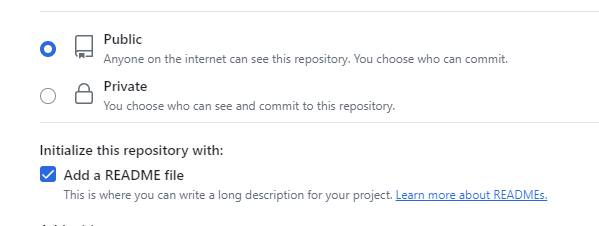

GitHub will display your profile README on your profile page if all of the following are true.

- You've created a repository with a name that matches your GitHub username.
- The repository is public.
- The repository contains a file named README.md in its root.
- The README.md file contains any content.

[More details](https://docs.github.com/en/account-and-profile/setting-up-and-managing-your-github-profile/customizing-your-profile/managing-your-profile-readme)

### Small Tricks to polish profile

#### Emoji

Copy [emojis](https://emojicopy.com/) and paste them in file

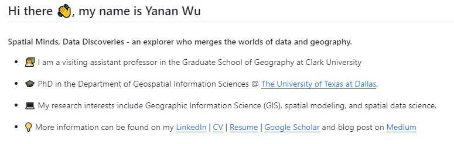

#### Static Bage

'any_text', 'you_like' and 'blue' are user-defined [Modify Static Bage per you needed](https://shields.io/badges)

For example is defined as https://img.shields.io/badge/My-LinkedIn-blue

Format that create a LinkedIn badge that connect to your associated account

- [![Alt text](link of badge)](link to content)

### Dynamic badges

[Dynamic badges](https://shields.io/badges/git-hub-repo-size) can show metrics for your repo or project.

## More about GitHub

### Modify Setting

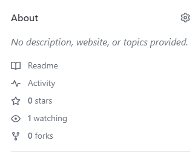

Modify Description, add url of Website, and add topics. Then save changes

- Topics in About section is clickable, click 'Python' to see the all repo that related to this topic! (This function is similar to # in Twitter)

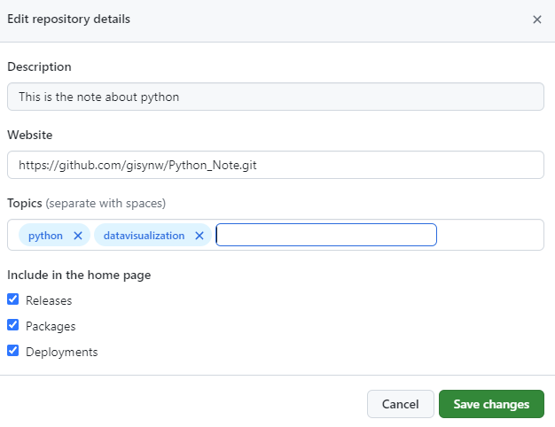

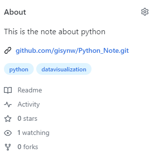

### Top Tabs

[figure not shown]

- Issues: Report issue about this repo (e.g., code error)
- Pull requests: Merge a set of changes from one branch into another
- Discussions: ask question or provide comments for the repo (You can hide or show disscussion through change setting in Settings)
  - You can insert image, code in the Discussio
- Action: show change in the repo
- Insights: Metrics (e.g., how many people visit your ) about your repo; Referrring sites; Popular content

## Install VS code

[Download link](https://code.visualstudio.com/)

### Create a Jupyter Notebook

Named Jupyter Notebook with anyname and end with .ipynb

## Git

### Install

Go to the [Git](https://git-scm.com/) website to download the installer for your operation system

### set up account name and email address

Set up your account name and email address in Git

- [Setting your username in Git](https://docs.github.com/en/get-started/getting-started-with-git/setting-your-username-in-git)
- [Setting your commit email address](https://docs.github.com/en/account-and-profile/setting-up-and-managing-your-personal-account-on-github/managing-email-preferences/setting-your-commit-email-address)

### Clone Repo from remote to local

- Clone a remote repository to local computer

```
git clone <repository_url>
```

### Push change from local to Remote

- Make some change to local repository, then update the remote pository based on Step 1 - 3.
1. To add files to the staging area, run the following command:

```
git add .
```

2. To commit the changes, run the following command. Repalce message with your comment to this commit

```
git commit -m 'message'
```

3. Push the change from local repository to remote repository

```
git push
```

### Pull change from Remote to local

```
git pull
```

## Inspect HTML

Right click, select 'Inspect'

### Elements

- show the structure of HTML

Then you can try to modify the Structure of HTML